# Tugas Praktikum 4

M.Syauqyi Habibi

2026-09-17

## Packages

```r
library(TSA)
```

## Fungsi Pembangkitan Umum

Sesuai dengan materi Pertemuan 4, pembangkitan data ARMA secara manual dilakukan menggunakan fungsi umum `arma.sim()` yang memanfaatkan perkalian koefisien AR/MA dengan data/*white noise* sebelumnya. Fungsi ini bersifat fleksibel karena dapat digunakan untuk membangkitkan proses MA murni (`arcoef = 0`), AR murni (`macoef = 0`), maupun ARMA campuran.

```r
arma.sim <- function(n, macoef, arcoef){
  manum <- length(macoef)
  arnum <- length(arcoef)
  stopifnot(manum < n & arnum < n)

  wn <- rnorm(n, sd = 0.5)
  init <- max(manum, arnum)

  arma <- wn[1:init]
  for(i in {init+1}:n){
   mastart <- i - manum
   maend <- i-1
   arstart <- i - arnum
   arend <- i-1
   arma[i] <- sum(arcoef * arma[arstart:arend]) + sum(macoef * wn[mastart:maend])  + wn[i]
   }
  return(arma)
}
```

# Proses MA(2)

Proses MA(2):

$$Y_t = e_t + \theta_1 e_{t-1} + \theta_2 e_{t-2}$$

dibangkitkan proses MA(2) dengan $\theta_1 = 0.4$ dan $\theta_2 = 0.6$ sebanyak 300 observasi.

## Pembangkitan Proses MA(2)

### Cara Manual (fungsi `arma.sim`)

```r
theta1 <- 0.4
theta2 <- 0.6

set.seed(1234)
ma2 <- arma.sim(n = 300, macoef = c(theta1, theta2), arcoef = 0)
ma2
```

```
##   [1] -0.6035328747  0.1387146211  0.3840362111 -0.7920306499 -0.2722587310
##   [6] -0.0873741878 -0.0497282747 -0.3445267375 -0.5611635483 -0.7236808854
##  [11] -0.6184980984 -0.8203585982 -0.7830814207 -0.4003240487  0.3438338957
##  [16]  0.2455972340 -0.0966915894 -0.6309576589 -0.7941463663  0.7745270018
##  [21]  0.6243603276  0.2780505534 -0.3406620612 -0.0005068205 -0.2970928656
##  [26] -0.8403006411 -0.2858276621 -0.6290421273 -0.1997147229 -0.6772469353
##  [31]  0.2673365327 -0.0942969958 -0.2769384332 -0.5585796573 -1.1068121602
##  [36] -1.1727892839 -1.7661242969 -1.5580323432 -0.9854528168 -0.5894355663
##  [41]  0.5261200988 -0.1926519903 -0.4583758809 -0.6106494358 -0.7524298655
##  [46] -0.8386837822 -1.0430814069 -1.1518912642 -0.8589734637 -0.6559705915
##  [51] -1.1568362394 -0.9322173308 -1.0902738410 -0.9565630770 -0.6074212895
##  [56]  0.0298426505  0.9603635774  0.2202796937  0.9005122818 -0.2518020700
##  [61]  0.3021335936  1.2399103651  0.8786348192  0.1645533074 -0.2116445297
##  [66]  0.7523340814 -0.0376994851  0.6977481583  0.8474090019  0.8406712717
##  [71]  0.3703012165 -0.1583719581 -0.3185240202  0.1230923563  1.1563166143
```

[output cut: 45 more lines]

### Cara `arima.sim()`

```r
set.seed(1234)
ma2.sim <- arima.sim(list(order = c(0, 0, 2), ma = c(theta1, theta2)), n = 300)
ma2.sim
```

```
## Time Series:
## Start = 1
## End = 300
## Frequency = 1
##   [1]  0.471173424 -1.745463687  0.141510314 -0.729712854 -0.114842790
##   [6] -0.472894305 -1.127948717 -1.443797742 -1.171879031 -1.723286222
##  [11] -1.461924092 -0.845074607  0.519525249  0.312187420  0.020572732
##  [16] -1.181770516 -1.508255550  1.534249256  0.598119283  1.012450498
##  [21] -0.556369299 -0.011041246 -0.774213194 -1.449939345 -0.420758391
##  [26] -1.662676381 -0.079747157 -1.556197355  0.718835126 -0.596243221
##  [31] -0.238298741 -1.070389923 -2.255260716 -2.120011486 -3.624543435
##  [36] -2.913580609 -2.138714925 -1.388210999  1.086560934 -0.768382742
##  [41] -0.413123964 -1.263954490 -1.619808057 -1.534624150 -2.091327966
##  [46] -2.276021753 -1.689013389 -1.457572736 -2.319068111 -1.602598402
##  [51] -2.425338748 -1.807763414 -1.233628102 -0.110845196  1.775654086
```

[output cut: 49 more lines]

## Karakteristik MA(2)

### Plot Time Series

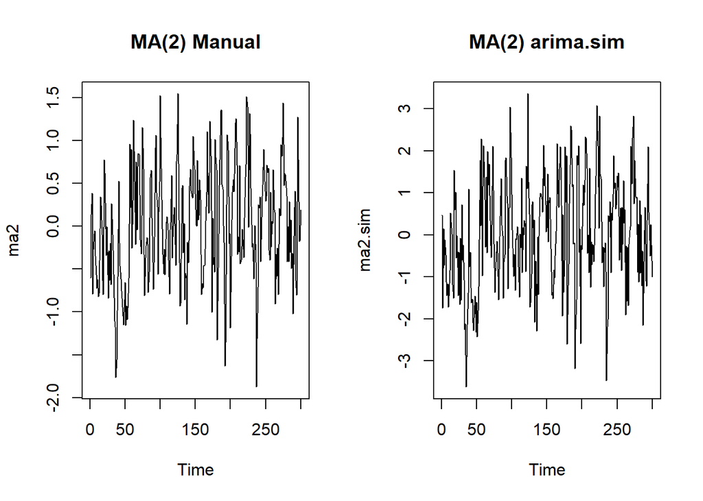

```r
par(mfrow = c(1, 2))
ts.plot(ma2, main = "MA(2) Manual")
ts.plot(ma2.sim, main = "MA(2) arima.sim")
```

```r
par(mfrow = c(1, 1))
```

Berdasarkan plot time series di atas, kedua data hasil pembangkitan (manual maupun `arima.sim`) bergerak di sekitar nilai tengah yang konstan tanpa tren maupun perubahan ragam yang mencolok, sehingga data MA(2) yang dibangkitkan dapat diidentifikasi **stasioner dalam rataan**. Hal ini sejalan dengan teori bahwa proses MA selalu stasioner untuk sembarang nilai koefisien $\theta$.

### Plot ACF

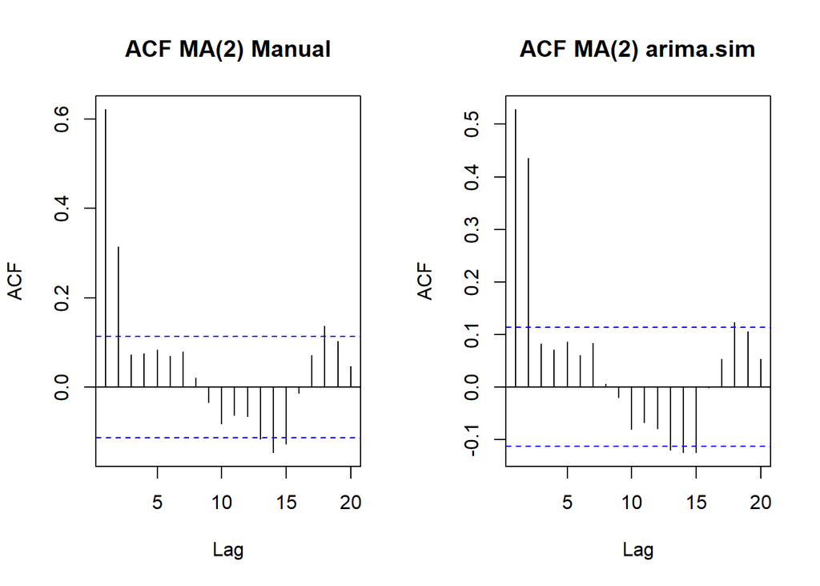

```r
par(mfrow = c(1, 2))
acf(ma2, lag.max = 20, main = "ACF MA(2) Manual")
acf(ma2.sim, lag.max = 20, main = "ACF MA(2) arima.sim")
```

```r
par(mfrow = c(1, 1))
```

Berdasarkan plot ACF tersebut, terlihat bahwa plot ACF **cuts off** setelah lag ke-2, sesuai dengan teori bahwa proses MA(q) memiliki ACF yang signifikan hanya sampai lag ke-q kemudian terputus.

### Plot PACF

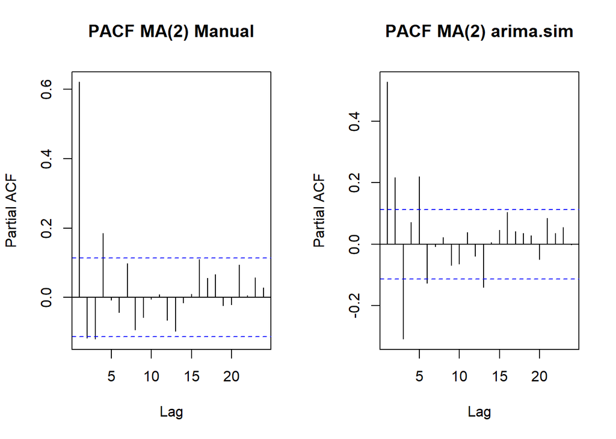

```r
par(mfrow = c(1, 2))
pacf(ma2, main = "PACF MA(2) Manual")
pacf(ma2.sim, main = "PACF MA(2) arima.sim")
```

```r
par(mfrow = c(1, 1))
```

Berdasarkan plot PACF tersebut, terlihat bahwa plot PACF cenderung **tails off** dan membentuk pola gelombang sinus/eksponensial menurun, sesuai dengan karakteristik teoritis proses MA.

### Plot EACF

```r
TSA::eacf(ma2)
```

```
## AR/MA
##   0 1 2 3 4 5 6 7 8 9 10 11 12 13
## 0 x x o o o o o o o o o  o  o  x
## 1 x x x o o o o o o o o  o  o  o
## 2 x x x o o o o o o o o  o  o  o
## 3 x x x x x o o o o o o  o  o  o
## 4 o x x o o o o o o o o  o  o  o
## 5 x o x x x x x o o o o  o  o  o
## 6 x x o x x o x x o o o  o  o  o
## 7 x x o x x o x o o o o  o  o  o
```

```r
TSA::eacf(ma2.sim)
```

```
## AR/MA
##   0 1 2 3 4 5 6 7 8 9 10 11 12 13
## 0 x x o o o o o o o o o  o  x  x
## 1 x x x o o o o o o o o  o  o  o
## 2 x x x x o o o o o o o  o  o  o
## 3 x x x x o o o o o o o  o  o  o
## 4 x x x x o o o o o o o  o  o  o
## 5 x x o x x o x o o o o  o  o  o
## 6 o x o o x o o x o o o  o  o  o
## 7 x o x o x o o x o o o  o  o  o
```

Berdasarkan pola segitiga nol pada plot EACF, segitiga nol diharapkan berada pada ordo AR(0) dan ordo MA(2), yang mengonfirmasi proses MA(2) yang dibangkitkan.

## Scatterplot Antar Lag (Data Manual)

```r
n <- length(ma2)
```

### Korelasi antara $Y_t$ dengan $Y_{t-1}$

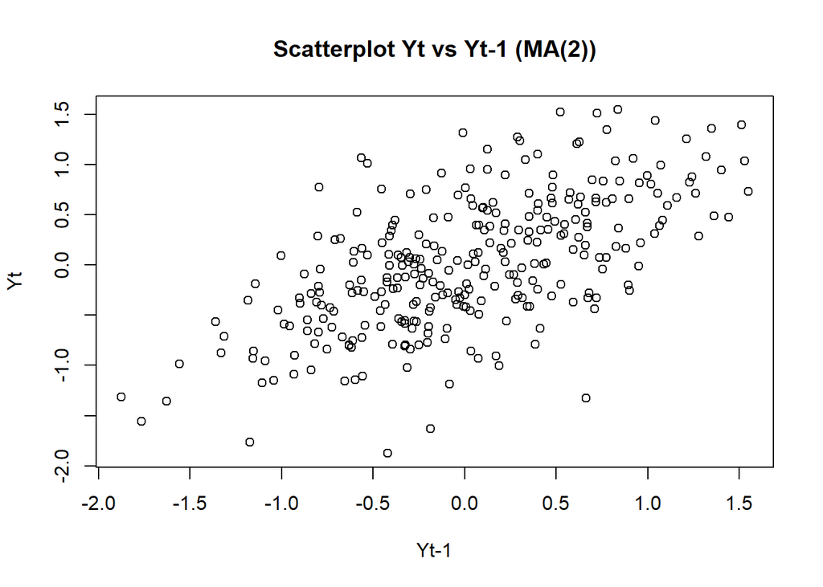

```r
yt <- ma2[-1]
yt_1 <- ma2[-n]
plot(y = yt, x = yt_1, xlab = "Yt-1", ylab = "Yt",
     main = "Scatterplot Yt vs Yt-1 (MA(2))")
```

```r
cor(yt, yt_1)
```

```
## [1] 0.6217886
```

### Korelasi antara $Y_t$ dengan $Y_{t-2}$

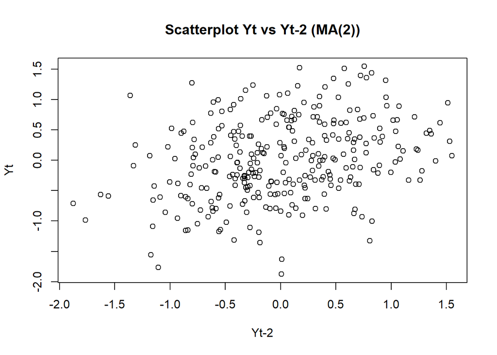

```r
yt <- ma2[-c(1, 2)]
yt_2 <- ma2[-c(n - 1, n)]
plot(y = yt, x = yt_2, xlab = "Yt-2", ylab = "Yt",
     main = "Scatterplot Yt vs Yt-2 (MA(2))")
```

```r
cor(yt, yt_2)
```

```
## [1] 0.3142303
```

### Korelasi antara $Y_t$ dengan $Y_{t-3}$

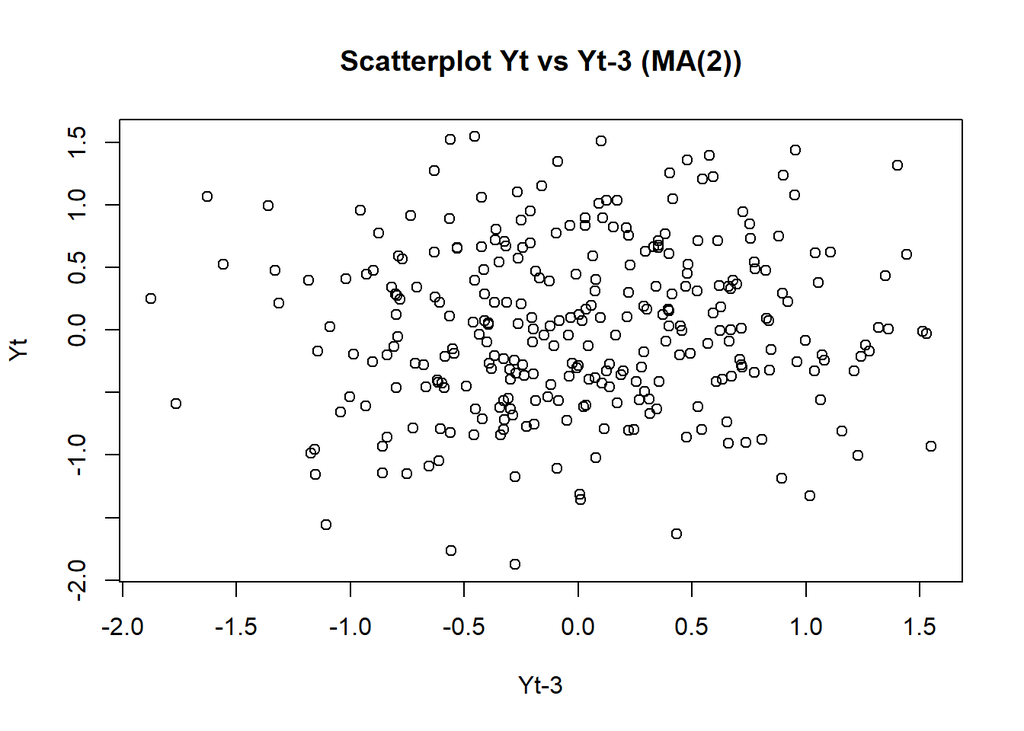

```r
yt <- ma2[-c(1, 2, 3)]
yt_3 <- ma2[-c(n - 2, n - 1, n)]
plot(y = yt, x = yt_3, xlab = "Yt-3", ylab = "Yt",
     main = "Scatterplot Yt vs Yt-3 (MA(2))")
```

```r
cor(yt, yt_3)
```

```
## [1] 0.07247897
```

Berdasarkan scatterplot dan nilai korelasi di atas, hubungan antara $Y_t$ dengan $Y_{t-1}$ dan $Y_{t-2}$ diharapkan cukup terlihat (sesuai orde MA(2)), sedangkan hubungan antara $Y_t$ dengan $Y_{t-3}$ diharapkan lemah/mendekati nol karena sudah melebihi orde MA.

## Autokorelasi MA(2): Empirik vs Teoritis

Autokorelasi teoritis untuk proses MA(2) dirumuskan sebagai:

$$\rho_1 = \frac{\theta_1 + \theta_1\theta_2}{1+\theta_1^2+\theta_2^2},
\quad
\rho_2 = \frac{\theta_2}{1+\theta_1^2+\theta_2^2}, \quad
\rho_k = 0 \; \text{untuk } k \ge 3$$

```r
rho1_teori_ma2 <- (theta1 + theta1 * theta2) / (1 + theta1^2 + theta2^2)
rho2_teori_ma2 <- theta2 / (1 + theta1^2 + theta2^2)
c(rho1 = rho1_teori_ma2, rho2 = rho2_teori_ma2, rho3 = 0)
```

```
##      rho1      rho2      rho3
## 0.4210526 0.3947368 0.0000000
```

Nilai di atas dapat pula diperiksa menggunakan fungsi bawaan R `ARMAacf()`:

```r
ARMAacf(ma = c(theta1, theta2), lag.max = 3)
```

```
##         0         1         2         3
## 1.0000000 0.4210526 0.3947368 0.0000000
```

```r
data.frame(
  Lag = 1:3,
  Empirik = c(cor(ma2[-1], ma2[-n]),
              cor(ma2[-c(1,2)], ma2[-c(n-1,n)]),
              cor(ma2[-c(1,2,3)], ma2[-c(n-2,n-1,n)])),
  Teoritis = c(rho1_teori_ma2, rho2_teori_ma2, 0)
)
```

```
##   Lag    Empirik  Teoritis
## 1   1 0.62178863 0.4210526
## 2   2 0.31423033 0.3947368
## 3   3 0.07247897 0.0000000
```

Nilai autokorelasi hasil bangkitan (empirik) diharapkan mendekati nilai autokorelasi teoritis, dengan autokorelasi pada lag 1 dan 2 bernilai signifikan (tidak nol) sedangkan lag 3 dan seterusnya mendekati nol, sesuai sifat proses MA(2).

# Proses AR(2)

Proses AR(2):

$$Y_t = \phi_1 Y_{t-1} + \phi_2 Y_{t-2} + e_t$$

dibangkitkan proses AR(2) dengan $\phi_1 = 0.5$ dan $\phi_2 = 0.2$ sebanyak 300 observasi.

## Pembangkitan Proses AR(2)

### Cara Manual (fungsi `arma.sim`)

```r
phi1 <- 0.5
phi2 <- 0.2

set.seed(1234)
ar2 <- arma.sim(n = 300, macoef = 0, arcoef = c(phi1, phi2))
ar2
```

```
##   [1] -0.603532875  0.138714621  0.268197075 -1.049852126  0.138690457
##   [6] -0.244160025 -0.266856757 -0.448767292 -0.505407836 -0.770484128
##  [11] -0.645397094 -1.013514705 -0.913528435 -0.657233631 -0.108463914
##  [16] -0.405452345 -0.390827179 -0.736489317 -0.761297293  0.687413472
##  [21] -0.176121842  0.063139419 -0.295706973  0.202223036 -0.454269003
##  [26] -0.713844738 -0.082525589 -0.885255348 -0.225883014 -0.955778578
##  [31]  0.247051551 -0.666275518 -0.364449347 -0.656656659 -1.128102740
##  [36] -1.137758508 -1.881622896 -1.615700429 -1.411098463 -1.323018678
##  [41] -0.245404835 -1.244911668 -0.799367068 -0.922640748 -1.081381722
##  [46] -1.161853877 -1.326720733 -1.472264028 -1.219727231 -1.228502439
##  [51] -1.758579732 -1.257005128 -1.685135704 -1.473010710 -1.218324756
##  [56] -0.698642396  0.075017879 -0.720994334  0.696264887 -0.800148464
##  [61]  0.516396983  0.977700700  0.436358437  0.241305248  0.262637890
##  [66]  1.061722426 -0.225640438  1.169646715  0.785891519  0.910238060
##  [71]  0.578439791  0.343072619  0.174572453  0.530594084  1.228540474
```

[output cut: 45 more lines]

### Cara `arima.sim()`

```r
set.seed(1234)
ar2.sim <- arima.sim(list(order = c(2, 0, 0), ar = c(phi1, phi2)), n = 300)
ar2.sim
```

```
## Time Series:
## Start = 1
## End = 300
## Frequency = 1
##   [1] -1.7066325607 -0.4040571790 -1.5670108246 -0.8794551485 -1.6890783403
##   [6]  0.0818673463 -0.7724750738 -1.0793041051 -1.1954051279 -2.4426568541
##  [11] -2.6280287147 -3.9825853771 -3.8578916236 -3.0197567460 -2.7473542381
##  [16] -0.5281322030 -1.8821796728 -1.9020809107 -1.6080993919 -2.1788059544
##  [21] -2.3795371734 -2.7328479702 -3.0943173054 -2.6175563658 -2.4244916012
##  [26] -3.5417883306 -2.8378684102 -3.2361814957 -3.2006264394 -2.4098590424
##  [31] -1.2819989901  0.5248461693 -0.7673301373  1.3272137941 -0.6476676781
##  [36]  0.5981973841  2.7185562271  1.4441572006  0.5961562661  0.5793048174
##  [41]  2.1859681101  0.0702372818  1.8401394423  2.2636819683  1.8363416698
##  [46]  1.3778000670  0.6006996293  0.2093858952  0.8731194410  2.5487077608
##  [51]  1.2955793561 -0.2331697165 -0.5810507641 -0.0788975632 -0.4727180494
```

[output cut: 49 more lines]

## Kondisi Kestasioneran AR(2)

Proses AR(2) stasioner apabila memenuhi syarat berikut:

$$\phi_1+\phi_2<1, \quad \phi_2-\phi_1<1, \quad |\phi_2|<1$$

```r
c(syarat1 = phi1 + phi2 < 1,
  syarat2 = phi2 - phi1 < 1,
  syarat3 = abs(phi2) < 1)
```

```
## syarat1 syarat2 syarat3
##    TRUE    TRUE    TRUE
```

Karena ketiga syarat terpenuhi, maka secara teoritis proses AR(2) dengan $\phi_1 = 0.5$ dan $\phi_2 = 0.2$ bersifat **stasioner**.

## Karakteristik AR(2)

### Plot Time Series

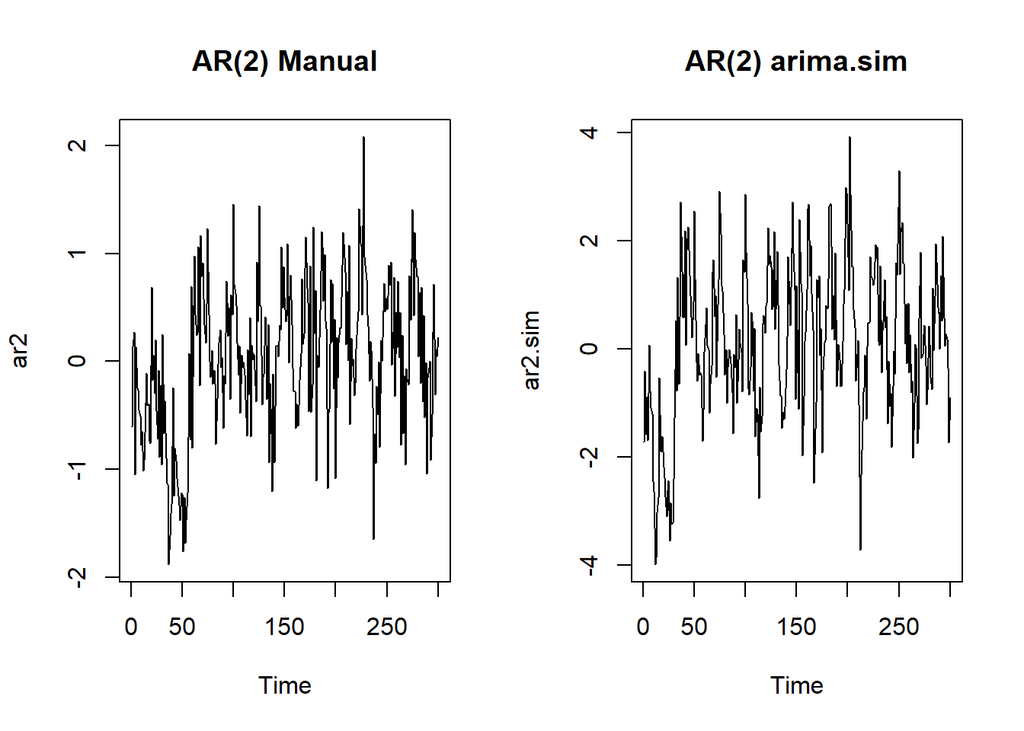

```r
par(mfrow = c(1, 2))
ts.plot(ar2, main = "AR(2) Manual")
ts.plot(ar2.sim, main = "AR(2) arima.sim")
```

```r
par(mfrow = c(1, 1))
```

Berdasarkan plot time series tersebut, data bergerak di sekitar nilai tengah yang konstan sehingga data AR(2) hasil bangkitan dapat diidentifikasi stasioner dalam rataan.

### Plot ACF

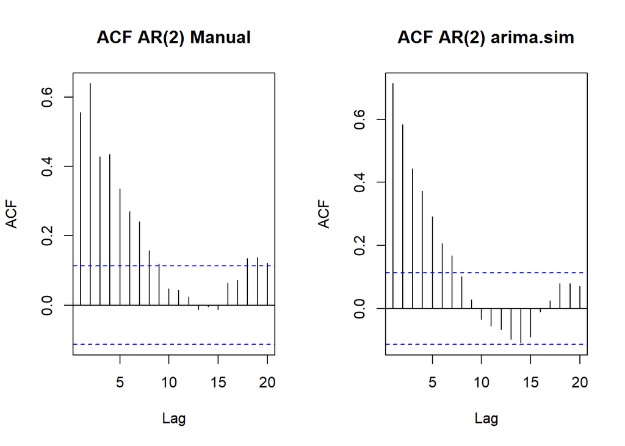

```r
par(mfrow = c(1, 2))
acf(ar2, lag.max = 20, main = "ACF AR(2) Manual")
acf(ar2.sim, lag.max = 20, main = "ACF AR(2) arima.sim")
```

```r
par(mfrow = c(1, 1))
```

Berdasarkan plot ACF tersebut, terlihat bahwa plot ACF cenderung **tails off** membentuk pola menurun/gelombang sinus, sesuai karakteristik teoritis proses AR.

### Plot PACF

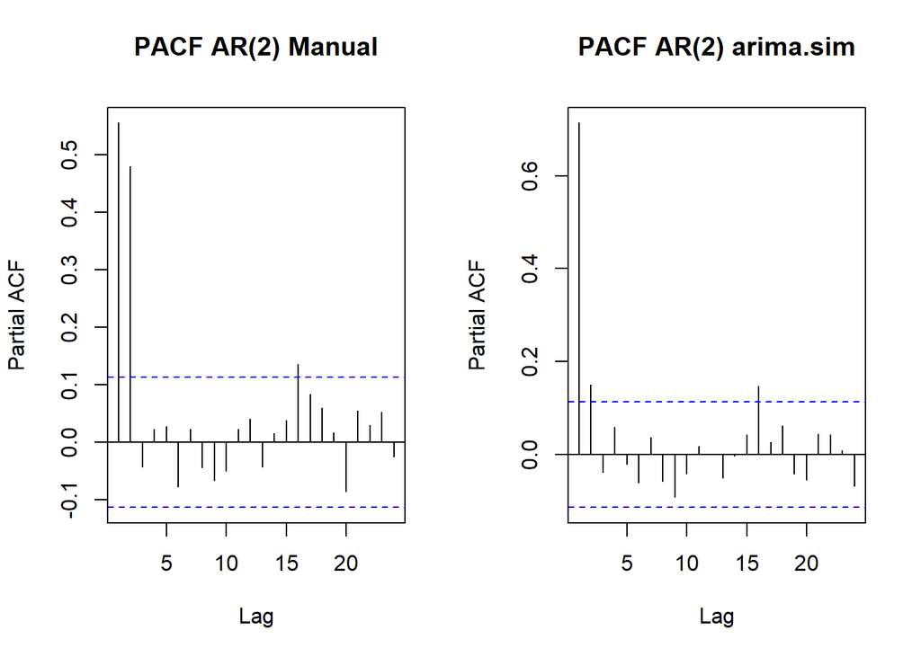

```r
par(mfrow = c(1, 2))
pacf(ar2, main = "PACF AR(2) Manual")
pacf(ar2.sim, main = "PACF AR(2) arima.sim")
```

```r
par(mfrow = c(1, 1))
```

Berdasarkan plot PACF tersebut, terlihat bahwa plot PACF **cuts off** setelah lag ke-2, sejalan dengan teori bahwa proses AR(p) memiliki PACF yang signifikan hanya sampai lag ke-p.

### Plot EACF

```r
TSA::eacf(ar2)
```

```
## AR/MA
##   0 1 2 3 4 5 6 7 8 9 10 11 12 13
## 0 x x x x x x x x x o o  o  o  o
## 1 x x x x o o o o o o o  o  o  o
## 2 o o o x o o o o o o o  o  o  o
## 3 x o o o o o o o o o o  o  o  o
## 4 x x o o o o x o o o o  o  o  o
## 5 x x x o o o o o o o o  o  o  o
## 6 x x x o o o o x o o o  o  o  o
## 7 x x x o x x o x o o o  o  o  o
```

```r
TSA::eacf(ar2.sim)
```

```
## AR/MA
##   0 1 2 3 4 5 6 7 8 9 10 11 12 13
## 0 x x x x x x x o o o o  o  o  o
## 1 x o o o o o o o o o o  o  o  o
## 2 x o o o o o o o o o o  o  o  o
## 3 x x o o o o o o o o o  o  o  o
## 4 x x o o o o o o o o o  o  o  o
## 5 x x x o o o o o o o o  o  o  o
## 6 x x x o o o o o o o o  o  o  o
## 7 x x x o x x o o o o o  o  o  o
```

Berdasarkan pola segitiga nol pada plot EACF, segitiga nol diharapkan berada pada ordo AR(2) dan ordo MA(0), yang mengonfirmasi proses AR(2) yang dibangkitkan.

## Scatterplot Antar Lag (Data Manual)

```r
n <- length(ar2)
```

### Korelasi antara $Y_t$ dengan $Y_{t-1}$

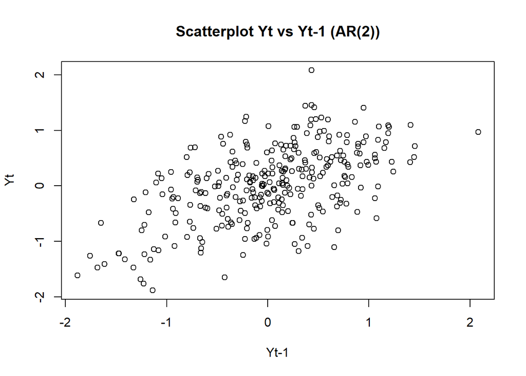

```r
yt <- ar2[-1]
yt_1 <- ar2[-n]
plot(y = yt, x = yt_1, xlab = "Yt-1", ylab = "Yt",
     main = "Scatterplot Yt vs Yt-1 (AR(2))")
```

```r
cor(yt, yt_1)
```

```
## [1] 0.5560506
```

### Korelasi antara $Y_t$ dengan $Y_{t-2}$

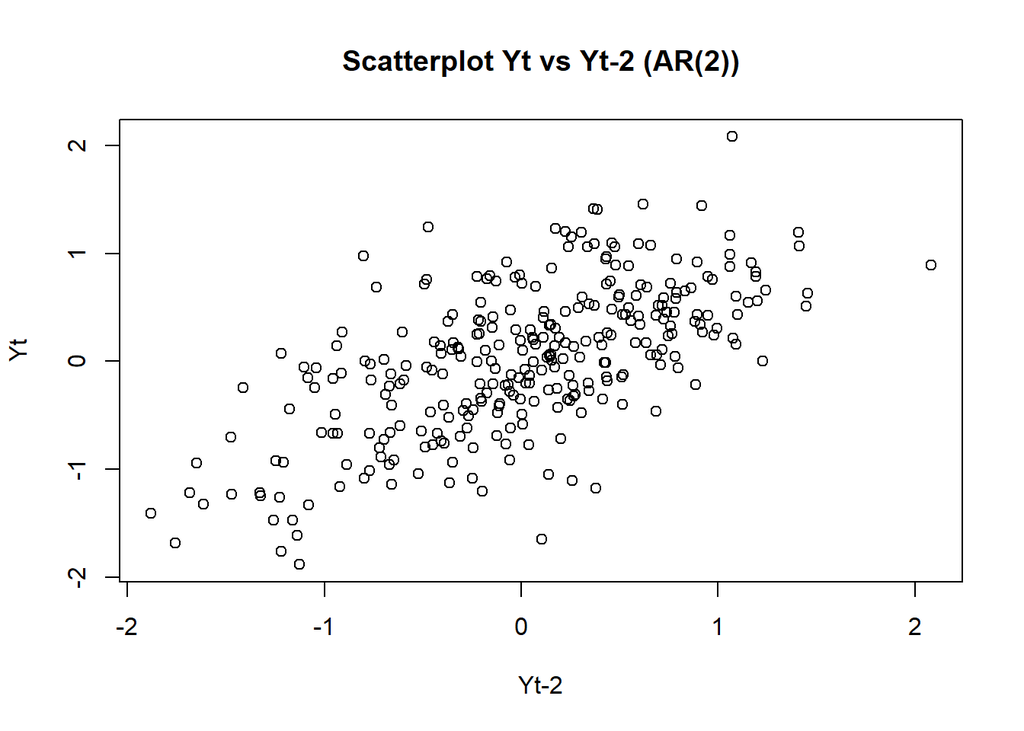

```r
yt <- ar2[-c(1, 2)]
yt_2 <- ar2[-c(n - 1, n)]
plot(y = yt, x = yt_2, xlab = "Yt-2", ylab = "Yt",
     main = "Scatterplot Yt vs Yt-2 (AR(2))")
```

```r
cor(yt, yt_2)
```

```
## [1] 0.6406007
```

### Korelasi antara $Y_t$ dengan $Y_{t-3}$

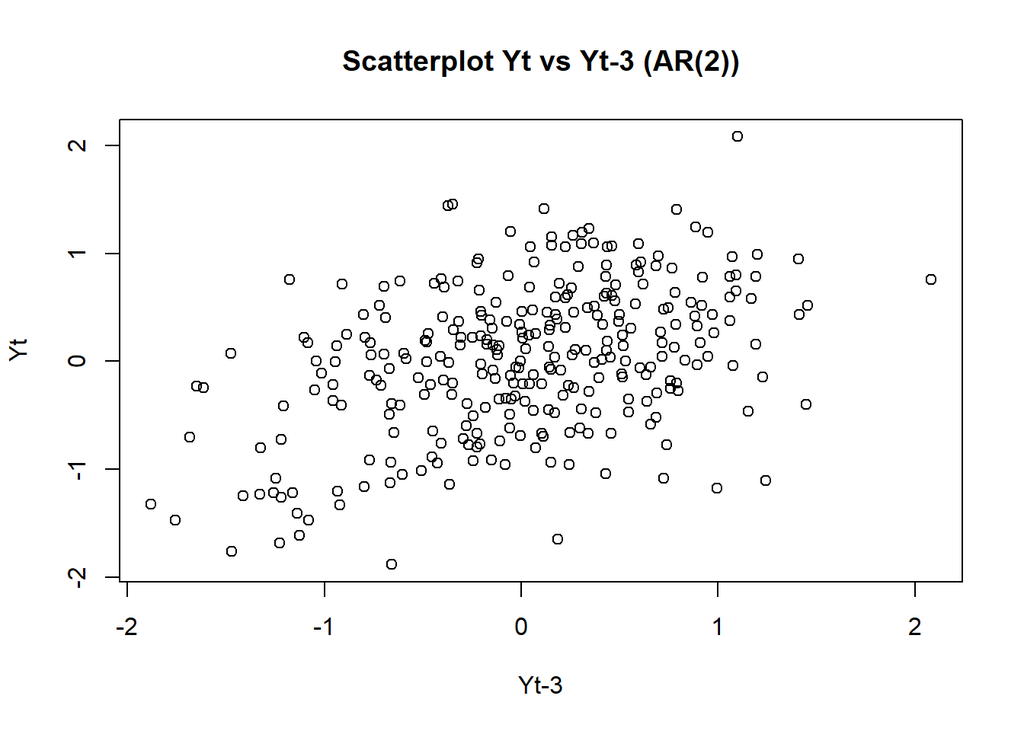

```r
yt <- ar2[-c(1, 2, 3)]
yt_3 <- ar2[-c(n - 2, n - 1, n)]
plot(y = yt, x = yt_3, xlab = "Yt-3", ylab = "Yt",
     main = "Scatterplot Yt vs Yt-3 (AR(2))")
```

```r
cor(yt, yt_3)
```

```
## [1] 0.4288158
```

## Autokorelasi AR(2): Empirik vs Teoritis

Autokorelasi teoritis proses AR(2) diperoleh melalui persamaan Yule-Walker:

$$\rho_1 = \frac{\phi_1}{1-\phi_2}, \quad
\rho_2 = \phi_2+\frac{\phi_1^2}{1-\phi_2}, \quad
\rho_k = \phi_1\rho_{k-1}+\phi_2\rho_{k-2} \; \text{untuk } k\ge3$$

```r
rho1_teori_ar2 <- phi1 / (1 - phi2)
rho2_teori_ar2 <- phi2 + phi1^2 / (1 - phi2)
rho3_teori_ar2 <- phi1 * rho2_teori_ar2 + phi2 * rho1_teori_ar2
c(rho1 = rho1_teori_ar2, rho2 = rho2_teori_ar2, rho3 = rho3_teori_ar2)
```

```
##    rho1    rho2    rho3
## 0.62500 0.51250 0.38125
```

Nilai di atas dapat pula diperiksa menggunakan fungsi bawaan R `ARMAacf()`:

```r
ARMAacf(ar = c(phi1, phi2), lag.max = 3)
```

```
##       0       1       2       3
## 1.00000 0.62500 0.51250 0.38125
```

```r
data.frame(
  Lag = 1:3,
  Empirik = c(cor(ar2[-1], ar2[-n]),
              cor(ar2[-c(1,2)], ar2[-c(n-1,n)]),
              cor(ar2[-c(1,2,3)], ar2[-c(n-2,n-1,n)])),
  Teoritis = c(rho1_teori_ar2, rho2_teori_ar2, rho3_teori_ar2)
)
```

```
##   Lag   Empirik Teoritis
## 1   1 0.5560506  0.62500
## 2   2 0.6406007  0.51250
## 3   3 0.4288158  0.38125
```

# Proses ARMA(2,2)

Proses ARMA(2,2) merupakan gabungan komponen AR(2) dan MA(2), dan dapat dituliskan sebagai berikut:

$$Y_t = \phi_1 Y_{t-1}+\phi_2 Y_{t-2}+e_t+\theta_1 e_{t-1}+\theta_2
e_{t-2}$$

Akan dibangkitkan proses ARMA(2,2) dengan $\theta_1=0.4$, $\theta_2=0.6$, $\phi_1=0.5$, dan $\phi_2=0.2$ sebanyak 300 observasi.

## Pembangkitan Proses ARMA(2,2)

### Cara Manual (fungsi `arma.sim`)

```r
set.seed(1234)
arma22 <- arma.sim(n = 300, macoef = c(theta1, theta2), arcoef = c(phi1, phi2))
arma22
```

```
##   [1] -0.603532875  0.138714621  0.110012698 -0.700670800 -0.357386542
##   [6] -0.509186896 -0.330258925 -0.665171971 -0.859327405 -1.228132352
##  [11] -1.293788271 -1.693182428 -1.768612042 -1.600637671 -0.860599659
##  [16] -0.726841534 -0.672359726 -1.128850371 -1.356096303 -0.061117444
##  [21] -0.065911313  0.234309569 -0.326755804  0.051296803 -0.450211407
##  [26] -0.904694521 -0.691872270 -1.219763842 -0.789603626 -1.445049581
##  [31] -0.416475197 -0.900116826 -0.665199397 -1.141677950 -1.667747448
##  [36] -2.077177748 -3.015433571 -3.199707932 -3.133111189 -2.815911770
##  [41] -1.603617849 -1.921331445 -1.644451095 -1.900205377 -1.954696488
##  [46] -2.179725769 -2.456374805 -2.733029109 -2.633766688 -2.549238484
##  [51] -2.983567280 -2.803550029 -3.142767487 -2.986891589 -2.776183351
##  [56] -2.018839814 -0.831496061 -0.955439425  0.293676366 -0.670786509
##  [61]  0.314814475  0.967480005  1.229538058  0.894200922  0.581964683
##  [66]  1.315827479  0.516448352  1.458951568  1.397423492  1.849631754
##  [71]  1.438939313  1.054231782  0.611791993  0.772566646  1.616725940
```

[output cut: 45 more lines]

### Cara `arima.sim()`

```r
set.seed(1234)
arma22.sim <- arima.sim(list(order = c(2, 0, 2),
                              ar = c(phi1, phi2),
                              ma = c(theta1, theta2)), n = 300)
arma22.sim
```

```
## Time Series:
## Start = 1
## End = 300
## Frequency = 1
##   [1] -2.75189059 -1.74814288 -2.98064692 -1.12111691 -1.75293106 -1.33898765
##   [7] -2.09046996 -3.56829323 -4.32225209 -6.49932813 -7.02769509 -6.95242810
##  [13] -6.26996407 -3.43890672 -3.74182891 -2.97181976 -3.49823015 -3.96328709
##  [19] -4.21591372 -4.99194225 -5.61517562 -5.49498965 -5.32810268 -6.08211738
##  [25] -5.70927763 -6.49640104 -6.19781946 -5.63181804 -4.16631811 -1.43386858
##  [31] -1.32659085  1.33518960 -0.57718012  1.13545868  2.56923465  2.89049818
##  [37]  2.80495292  1.68426168  2.77538382  1.29220743  3.17981524  3.04188012
##  [43]  3.84589813  3.47054592  2.25362466  1.27634579  1.31729358  3.02358708
##  [49]  2.83893413  1.81428668  0.10302896 -0.45121970 -0.85290753 -0.66635425
##  [55] -0.93510416 -2.14779642 -2.08562341 -1.51503473 -0.24121274  0.91556687
##  [61]  0.64537308  0.48311177 -1.14217407 -1.12039092 -1.27141453  0.91636167
```

[output cut: 39 more lines]

### Verifikasi Model melalui Pendugaan `arima()`

Sebagai pengecekan, data hasil bangkitan dapat diduga kembali parameternya menggunakan fungsi `arima()`. Jika pembangkitan sudah benar, koefisien dugaan seharusnya mendekati nilai parameter awal ($\phi_1=0.5$, $\phi_2=0.2$, $\theta_1=0.4$, $\theta_2=0.6$).

```r
arima(arma22, order = c(2, 0, 2))
```

```
##
## Call:
## arima(x = arma22, order = c(2, 0, 2))
##
## Coefficients:
##          ar1     ar2     ma1     ma2  intercept
##       0.2437  0.4892  0.6923  0.4865     0.0283
## s.e.  0.0801  0.0776  0.0765  0.0591     0.2288
##
## sigma^2 estimated as 0.2442:  log likelihood = -215.36,  aic = 440.73
```

## Karakteristik ARMA(2,2)

### Plot Time Series

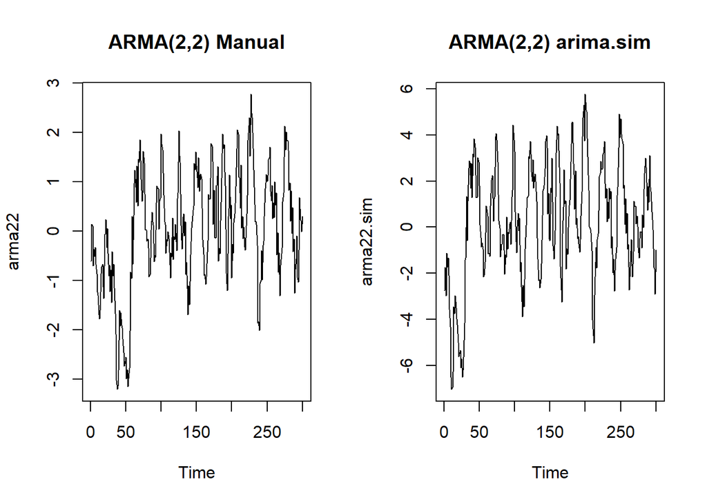

```r
par(mfrow = c(1, 2))
ts.plot(arma22, main = "ARMA(2,2) Manual")
ts.plot(arma22.sim, main = "ARMA(2,2) arima.sim")
```

```r
par(mfrow = c(1, 1))
```

Berdasarkan plot time series tersebut, data bergerak di sekitar nilai tengah yang konstan sehingga data ARMA(2,2) yang dibangkitkan dapat diidentifikasi **stasioner dalam rataan** (syarat kestasioneran dipenuhi oleh komponen AR-nya, yaitu $\phi_1+\phi_2 = 0.7 < 1$).

### Plot ACF

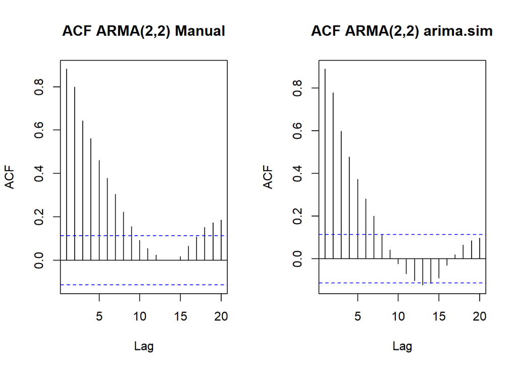

```r
par(mfrow = c(1, 2))
acf(arma22, lag.max = 20, main = "ACF ARMA(2,2) Manual")
acf(arma22.sim, lag.max = 20, main = "ACF ARMA(2,2) arima.sim")
```

```r
par(mfrow = c(1, 1))
```

Berdasarkan plot ACF tersebut, terlihat bahwa plot ACF proses ARMA(2,2) hasil bangkitan **tails off**, sesuai dengan teori bahwa proses campuran ARMA memiliki ACF yang meluruh secara bertahap tanpa terputus tegas seperti pada proses MA murni.

### Plot PACF

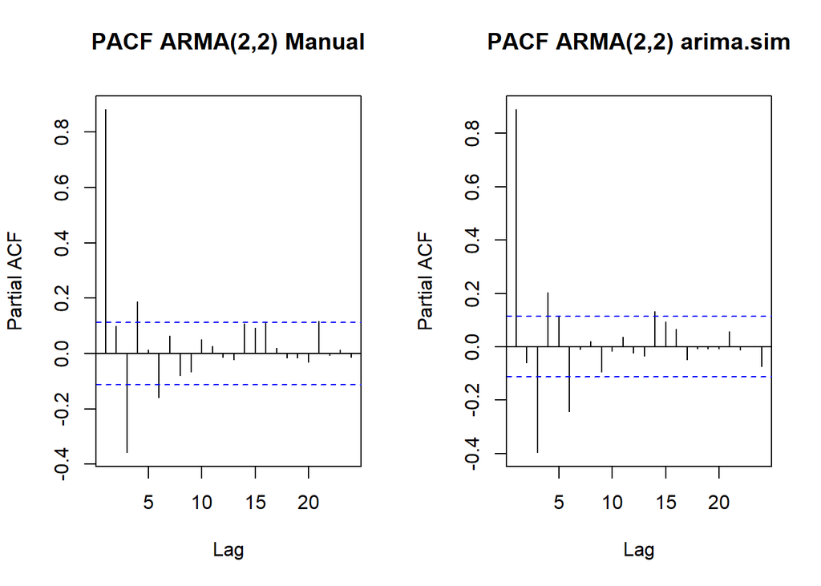

```r
par(mfrow = c(1, 2))
pacf(arma22, main = "PACF ARMA(2,2) Manual")
pacf(arma22.sim, main = "PACF ARMA(2,2) arima.sim")
```

```r
par(mfrow = c(1, 1))
```

Berdasarkan plot PACF tersebut, terlihat bahwa plot PACF juga **tails off**, sesuai teori bahwa kedua plot ACF dan PACF pada proses ARMA campuran umumnya sama-sama meluruh secara bertahap (tidak ada yang *cuts off* tegas).

### Plot EACF

```r
TSA::eacf(arma22)
```

```
## AR/MA
##   0 1 2 3 4 5 6 7 8 9 10 11 12 13
## 0 x x x x x x x x x o o  o  o  o
## 1 o x x x o o o o o o o  o  o  o
## 2 x x o x o o o o o o o  o  o  o
## 3 x x o o o o x o o o o  o  o  o
## 4 o x x o o o x o o o o  o  o  o
## 5 o x x x o o x o o o o  o  o  o
## 6 x x x x o o o o o o o  o  o  o
## 7 x x x x o x o o o o o  o  o  o
```

```r
TSA::eacf(arma22.sim)
```

```
## AR/MA
##   0 1 2 3 4 5 6 7 8 9 10 11 12 13
## 0 x x x x x x x o o o o  o  x  o
## 1 o x o o o o x o o o o  o  o  o
## 2 x x o o o o o o o o o  o  o  o
## 3 x x x x o o o o o o o  o  o  o
## 4 x x x x o o o o o o o  o  o  o
## 5 x x x x x x x o o o o  o  o  o
## 6 o o x o x x o o o o o  o  o  o
## 7 x o x x x x o x o o o  o  o  o
```

Berdasarkan pola segitiga nol pada plot EACF, segitiga nol diharapkan berada pada ordo AR(2) dan ordo MA(2), yang mengonfirmasi proses ARMA(2,2) yang dibangkitkan.

## Scatterplot Antar Lag (Data Manual)

```r
n <- length(arma22)
```

### Korelasi antara $Y_t$ dengan $Y_{t-1}$

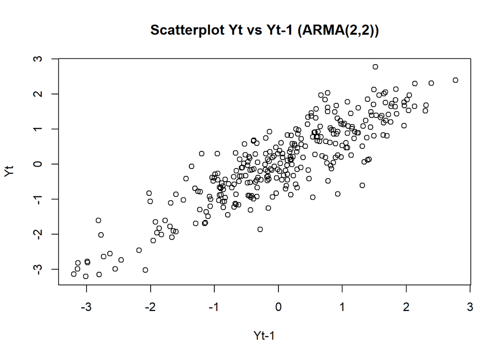

```r
yt <- arma22[-1]
yt_1 <- arma22[-n]
plot(y = yt, x = yt_1, xlab = "Yt-1", ylab = "Yt",
     main = "Scatterplot Yt vs Yt-1 (ARMA(2,2))")
```

```r
cor(yt, yt_1)
```

```
## [1] 0.8822069
```

### Korelasi antara $Y_t$ dengan $Y_{t-2}$

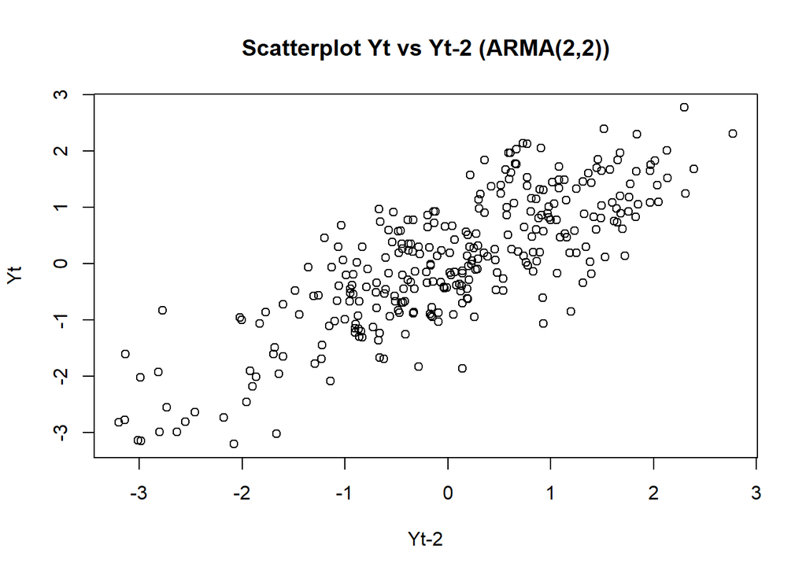

```r
yt <- arma22[-c(1, 2)]
yt_2 <- arma22[-c(n - 1, n)]
plot(y = yt, x = yt_2, xlab = "Yt-2", ylab = "Yt",
     main = "Scatterplot Yt vs Yt-2 (ARMA(2,2))")
```

```r
cor(yt, yt_2)
```

```
## [1] 0.7999128
```

### Korelasi antara $Y_t$ dengan $Y_{t-3}$

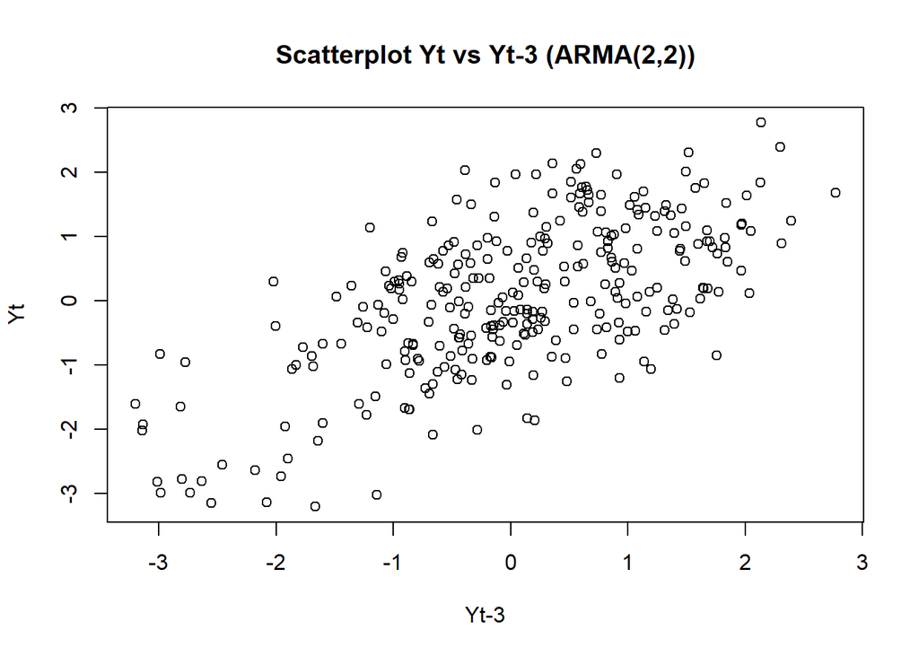

```r
yt <- arma22[-c(1, 2, 3)]
yt_3 <- arma22[-c(n - 2, n - 1, n)]
plot(y = yt, x = yt_3, xlab = "Yt-3", ylab = "Yt",
     main = "Scatterplot Yt vs Yt-3 (ARMA(2,2))")
```

```r
cor(yt, yt_3)
```

```
## [1] 0.6438762
```

Sama seperti proses AR, hubungan antara $Y_t$ dengan lag-lag sebelumnya pada proses ARMA(2,2) diharapkan tetap terlihat pada $Y_{t-1}$, $Y_{t-2}$, maupun $Y_{t-3}$ meskipun semakin melemah, karena komponen AR pada model menyebabkan autokorelasi meluruh secara bertahap dan tidak langsung terputus ke nol.

## Autokorelasi ARMA(2,2): Empirik vs Teoritis

Karena proses ARMA(2,2) merupakan campuran AR dan MA, autokorelasi teoritisnya lebih kompleks untuk diturunkan secara manual. Nilai autokorelasi teoritis dapat diperoleh langsung menggunakan fungsi bawaan R `ARMAacf()`:

```r
rho_teori_arma22 <- ARMAacf(ar = c(phi1, phi2), ma = c(theta1, theta2), lag.max = 3)
rho_teori_arma22
```

```
##         0         1         2         3
## 1.0000000 0.8591993 0.7491908 0.5464353
```

```r
data.frame(
  Lag = 1:3,
  Empirik = c(cor(arma22[-1], arma22[-n]),
              cor(arma22[-c(1,2)], arma22[-c(n-1,n)]),
              cor(arma22[-c(1,2,3)], arma22[-c(n-2,n-1,n)])),
  Teoritis = as.numeric(rho_teori_arma22[2:4])
)
```

```
##   Lag   Empirik  Teoritis
## 1   1 0.8822069 0.8591993
## 2   2 0.7999128 0.7491908
## 3   3 0.6438762 0.5464353
```

Nilai autokorelasi hasil bangkitan (empirik) diharapkan mendekati nilai autokorelasi teoritis pada setiap lag. Pola peluruhan yang bertahap (bukan terputus tegas seperti MA) menegaskan bahwa data ARMA(2,2) memiliki karakteristik campuran antara komponen AR dan MA.